# Where is the Money for Feminist Organizing? Survey for feminist, women’s rights and gender justice movements, groups and organizations

2024-09-09

#WITM follow up

**Database upload**

```r
# To upload CSV file
#datos <- read.csv2("Data/WITM_csv_last.csv")
datos <- read.csv("Data/WITM_final_cleaned_08_sept.csv")

# To upload xlsx file
#datos<- read_xlsx("WITM_xls_value2.xlsx", sheet = 1)
```

**Answers**

Number oi answers by date

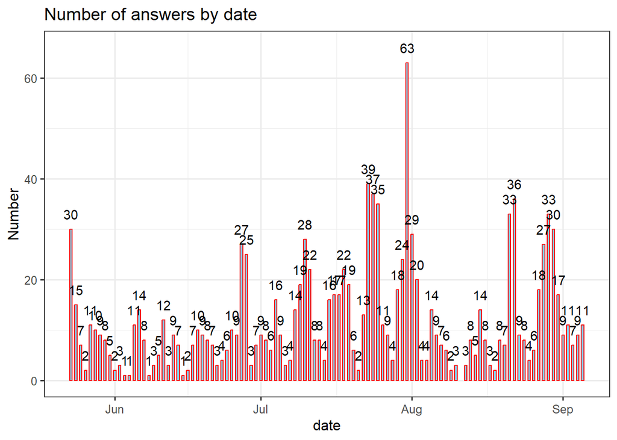

**Consent:**

Q1. I consent to take the WITM survey on behalf of my group, organization or movement.

| Consent | n | porcentaje |
| --- | --- | --- |
| yes | 1249 | 100 |

**Group information:**

Q2. Which of the following statements best describes your group, organization and/or movement?

| Description | n | porcentaje |
| --- | --- | --- |
| We promote the rights of women or girls or trans or gender diverse people with intersecting identities ‘through specific project(s)’, but not as the primary focus of our work | 232 | 18.6 |
| We promote the rights of women or girls or trans or gender diverse people in all their intersecting identities and this is the ‘primary focus of all our work’ | 924 | 74.0 |
| Other | 93 | 7.4 |

| Other |
| --- |
| 10%of my work |
| 60% of our work focus on marginalized communities in the composition of women, girls and PWDs |
| At the local communities where we work, their rights is of. Utmost importance. |
| Autonomisation et prévention à l’exploitation l’abus sexuel |
| Brindamos asesoría y acompañamiento gratuito a familias lideradas por mujeres y es un porcentaje mayor hacia donde va dirigida nuestra atención |
| Building and strengthening women’s and people’s movements for social justice and equality. |
| C’est que nous promouvons avec intensité les droits des personnes trans en tout ses genres divers. Et c’est ça notre objective principal. |
| Ces thématiques sont alignées sur notre programme 2022-2025 |
| Currently individual who contribute in Marsinah id a women’s worker based in Indonesia. |
| Dans le cadre de la lutte contre les VBG |
| Defensa y promocion de los derechos de las mujeres en toda su diversidad en especial mujeres con discapacidad |
| Derechos de las mujeres de diferentes sectores, niñas y jovenes |
| Derechos de las mujeres defensoras de los derechos de la naturaleza |
| Droit des femmes et filles |
| Empoderamiento de las mujeres valorando su rol para mejorar su condiciòn de inequidad en los hogares y en el rol social de la comunidad |
| Es el centro de nuestra misión institucional es el trabajo con niñas, adolescentes, jóvenes y mujeres Indígenas |
| Es prioridad en toda nuestra área de atecion, levantamiento de informacion y enfoque de protección. |
| Every woman should be treated with respect and their dignity should be respected as well |
| Gender Equality Diversity and INclusion is one of the three pillars of our work, the others being civic rights in a digital age and climate justice. |
| Girls and women with Disabilities |
| I am now like individual consultant, although I work with the UN before |
| I do not understand this question. We are an organisation that supports sex workers of all genders, but mainly female and trans workers. |
| I want them to live like every one not disrespect or discriminated |
| I’m Glad I’m a Girl Foundation seeks to engage girls and young women. |
| Ils sont pris en compte dès l’élaboration de nos plans d’actions jusqu’à l’exécution de nos actions et activités. |
| In our case management portfolio for SGBV and Child Protection and Children/adult safeguarding, we offer care to all who need it nonjudgmentally. |
| Labour rights |
| Los derechos de las mujeres desde la perspectiva de acceso a la educación, medios de comunicación y participación política |
| Mulheres lésbicas |
| Mulheres negras LGBTQIA |

[output cut: 62 more lines]

**Organization names:**

Q3. The name of your group, organization and/or movement

**Type of organization**

Q4. Which of the following forms of organizing best describes your group, organization and/or movement?

*This is a multiple-choice question so the sum of the % does NOT add up to 100.*

| Organization type | n | porcentaje |
| --- | --- | --- |
| Women’s rights | 913 | 73.1 |
| Ending gender based violence | 847 | 67.8 |
| Human rights | 719 | 57.6 |
| Sexual and reproductive health & rights (SRHR) and bodily autonomy | 668 | 53.5 |
| Young feminists | 457 | 36.6 |
| Economic justice, rights and alternatives | 409 | 32.7 |
| Climate and environmental justice | 393 | 31.5 |
| Human rights defenders at risk | 376 | 30.1 |
| Girls’ movements | 326 | 26.1 |
| Countering anti-gender and anti-rights | 311 | 24.9 |
| Lesbian, Bisexual and queer rights | 310 | 24.8 |
| Disability rights and justice | 288 | 23.1 |
| Rights for people living with HIV+ | 287 | 23.0 |
| Sex workers rights | 257 | 20.6 |
| Trans and non-binary rights | 253 | 20.3 |
| Holistic safety, protection and collective care | 251 | 20.1 |
| Indigenous rights | 250 | 20.0 |
| Displaced, migrant and refugee rights | 244 | 19.5 |
| Crisis response | 224 | 17.9 |
| Labour rights | 217 | 17.4 |
| Black rights/ Black feminist rights | 206 | 16.5 |
| Digital rights | 192 | 15.4 |
| Freedom of information and media | 159 | 12.7 |
| Racial justice | 154 | 12.3 |
| Pleasure and bodily care | 153 | 12.2 |
| Harm reduction | 146 | 11.7 |
| Intersex rights | 141 | 11.3 |
| Religious and ethnic minority rights | 125 | 10.0 |
| Anti-militarization and peace | 113 | 9.0 |
| Other | 64 | 5.1 |
| Resisting the war on drugs | 55 | 4.4 |
| Anti-caste | 52 | 4.2 |

**Register**

Q5. Is your group, organization and/or movement registered?

| Register | n | porcentaje |
| --- | --- | --- |
| Yes | 985 | 78.9 |
| Other | 32 | 2.6 |
| No | 212 | 17.0 |
| NA | 20 | 1.6 |

**Scope:**

Q6. What is the geographical scope of your work?

| Geo scope | n | porcentaje |
| --- | --- | --- |
| Work from diaspora, refuge and/or exile | 15 | 1.2 |
| Global | 74 | 5.9 |
| Locally | 391 | 31.3 |
| Nationally | 615 | 49.2 |
| Regionally | 123 | 9.8 |
| Transnationally | 31 | 2.5 |

**Region:**

Q7. Indicate in which region(s) your group, organization and/or movement works

| Region | n | porcentaje |
| --- | --- | --- |
| South America | 254 | 20.3 |
| East Africa | 203 | 16.3 |
| South Asia | 179 | 14.3 |
| Central America & Mexico | 175 | 14.0 |
| West Africa | 166 | 13.3 |
| Central Africa | 123 | 9.8 |
| Southeast Asia | 95 | 7.6 |
| Southern Africa | 94 | 7.5 |
| Caribbean | 83 | 6.6 |
| Eastern Europe, Southeast Europe and Central Europe | 83 | 6.6 |
| South West Asia/Middle East | 77 | 6.2 |
| Western Europe | 71 | 5.7 |
| North Africa | 68 | 5.4 |
| North America | 64 | 5.1 |
| The Pacific | 47 | 3.8 |
| Central Asia & Caucasus | 44 | 3.5 |
| East Asia | 41 | 3.3 |

**Country:**

Q8. Which countries are you working in?

| q7_region_one | q8_country | n |
| --- | --- | --- |
| East Africa | Kenya | 51 |
| East Africa | South Sudan | 7 |
| East Africa | Uganda | 43 |
| East Africa | Rwanda | 10 |
| East Africa | Burundi | 5 |
| East Africa | Tanzania | 14 |
| East Africa | Malawi | 3 |
| East Africa | Ethiopia | 3 |
| East Africa | Other East Africa | 3 |
| East Africa | Somalia | 2 |
| East Africa | Mozambique | 1 |
| East Africa | NA | 1 |
| North America | United States of America | 8 |
| North America | Canada | 11 |
| Central Africa | Democratic Republic of the Congo | 55 |
| Central Africa | Cameroon | 12 |
| Central Africa | Central African Republic | 4 |
| Central Africa | Chad | 6 |
| Central Africa | Angola | 1 |
| Central Africa | NA | 1 |
| Southeast Asia | Thailand | 3 |
| Southeast Asia | Malaysia | 4 |
| Southeast Asia | Indonesia | 11 |
| Southeast Asia | Cambodia | 4 |
| Southeast Asia | Myanmar | 8 |
| Southeast Asia | Philippines | 6 |
| Southeast Asia | Other Southeast Asia | 7 |
| Southeast Asia | Viet Nam | 1 |
| Southeast Asia | Singapore | 1 |
| Southeast Asia | NA | 3 |

[output cut: 106 more lines]

**Year of formation:**

Q9. What year was your group, organization and/ or movement formed?

| Year formation | total | porcentaje |
| --- | --- | --- |
| Año 2023 | 49 | 4.9 |
| Año 2022 | 53 | 5.3 |
| Año 2021 | 51 | 5.1 |
| Entre 2015 y 2020 | 343 | 34.1 |
| Entre 2010 y 2014 | 177 | 17.6 |
| Entre 2000 y 2009 | 207 | 20.6 |
| Antes del 2000 | 126 | 12.5 |

**External founding:**

Q13. Between 2021 and 2023, has your group, organization and/or movement received any external funding?

| External funding | n | porcentaje |
| --- | --- | --- |
| no | 312 | 31 |
| yes | 694 | 69 |

**Language:**

Q46. In which language did you answer the survey?

| Language | n | porcentaje |
| --- | --- | --- |
| Arabic | 33 | 3.3 |
| English | 488 | 48.5 |
| French | 140 | 13.9 |
| Portuguese | 43 | 4.3 |
| Russian | 4 | 0.4 |
| Spanish | 170 | 16.9 |
| NA | 128 | 12.7 |

Q45. Did anyone from your group, organization and/or movement respond to AWID’s Where is the Money survey in 2008 or 2011?

| Previous response | n | porcentaje |
| --- | --- | --- |
| Yes | 101 | 10.0 |
| No | 742 | 73.8 |
| Don’t know | 163 | 16.2 |